# phenomenological and mechanistic models in species distribution modeling

8 May 2017

## data sets

## diatoms

- 7 stream systems \(\times\) 15 samples  
  (105 samples total)
- 499 species
- *predictors*: shading, % particles, moss cover, water velocity, conductance, pH, water colour, total P
- use first 4 PCA axes

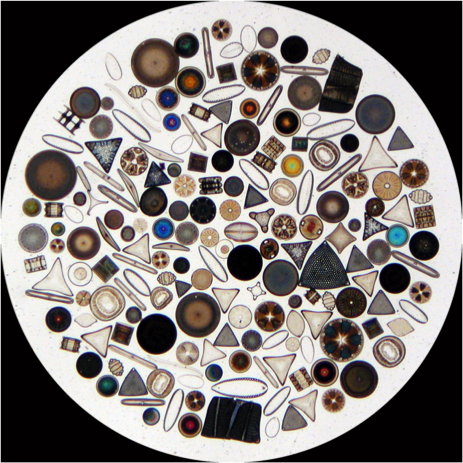

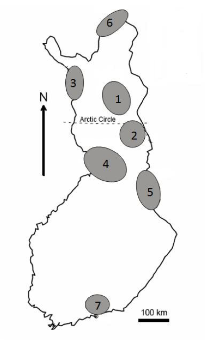

## fungi

- 29 forests  
  (21 managed, 8 natural)
- 22,500 samples (logs)
- 321 species
- *predictors*: management status, log (diameter), decay class, decay class\(^2\)

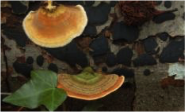

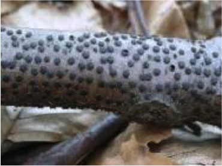

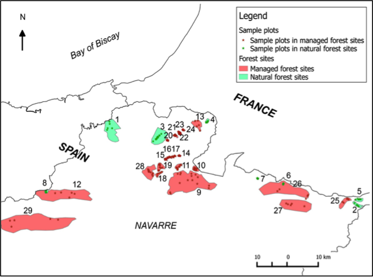

## UK butterflies

- 2841 10 km \(\times\) 10 km grid cells
- 55 species
- *predictors*: # growing days > 5 C, % broadleaf woodland, % coniferous woodland, % calcareous substrates

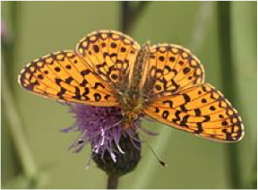

sp 1

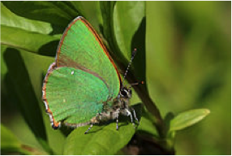

sp 2

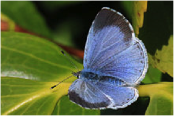

sp 3

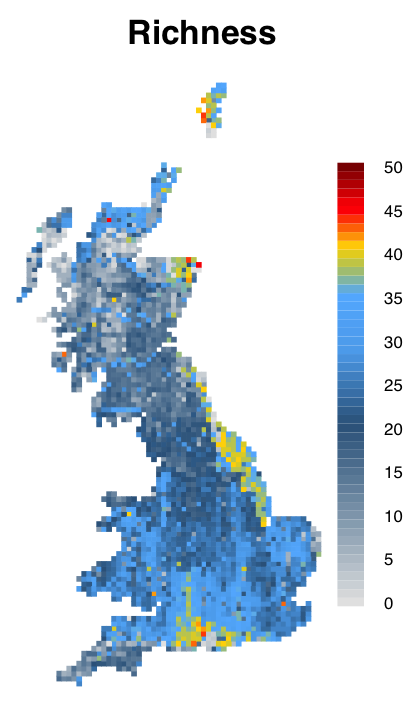

## Australian plants

- 30,000 locations (600)
- 2729 species
- salinity, wetness, rainfall

## US trees

- 100,000 locations (600)
- 590 species
- first 3 PCA axes (out of 38 climate and soil variables)

## models

## Univariate (stacked SDMs)

- fit each species independently
  - **algorithmic**: boosted regression trees, random forest, support vector machine, multivariate regression trees, MARS, gradient nearest neighbour …
  - **model-based**: GLM, GAM
- community-level predictions simply aggregate individual-species results

## Multivariate (joint SDMs)

- fit all species simultaneously, allow +/- dependencies
  - species archetype models (SAM)
  - neural networks (MISTNET)
  - hierarchical GLM (HMSC)
- potential improvement in accuracy
- more direct community-level predictions

## sampling

- hierarchical (discrete) vs. spatially explicit
- interpolation vs extrapolation
- some large data sets subsampled

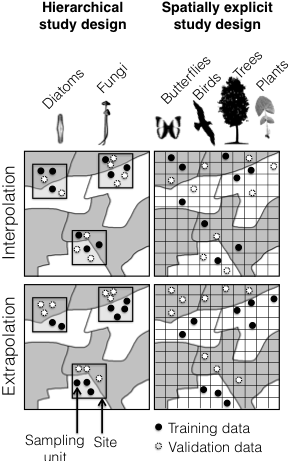

## assessment statistics

- joint models *could* improve individual predictions …
- … but more obvious effects on community-level response

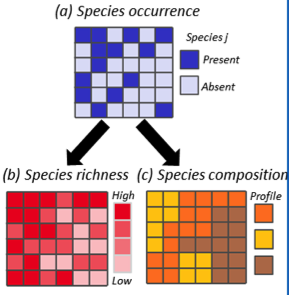

## results

## summary (terciles)

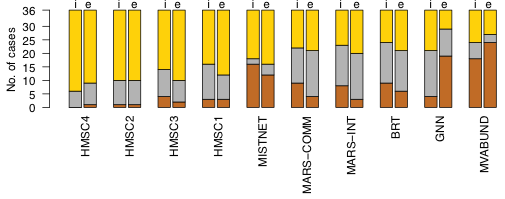

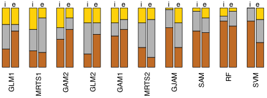

## summary (species occupancy: Tjur \(R^2\))

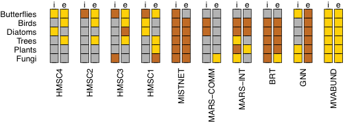

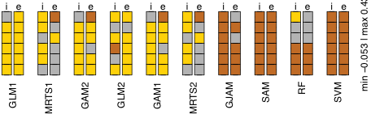

## summary (species occupancy: deviance)

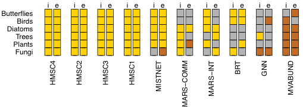

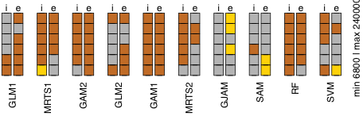

## summary (species richness: MSE per site)

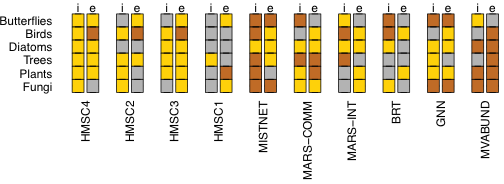

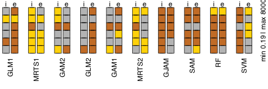

## discussion

## phenomenological/mechanistic

- definition is context-dependent, e.g.
  - linear, quadratic
  - Michaelis-Menten/Monod/Beverton-Holt
- many mechanisms per phenomenon:  
  cf. the *Strong Law of Small Numbers* (Guy 1988)
- **semimechanistic** models (e.g Merow et al. (2011))

## SDM extensions

- phylogenetic information
- dispersal
- trophic interactions

## model-based statistics

- ecological-mechanistic \(\leftrightarrow\)  
  model-based-statistical \(\leftrightarrow\)  
  algorithmic-statistical
- tradeoffs
  - identifiability
  - computational efficiency
  - interpretability
  - flexibility

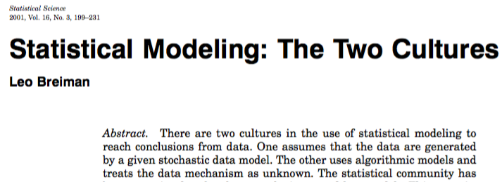

[figure not shown]

## References

Guy, RK. 1988. *The American Mathematical Monthly* 95 (8) (October): 697. doi:10.2307/2322249. http://www.jstor.org/stable/2322249?origin=crossref.

Merow, C et al. 2011. *The American Naturalist* 178 (1) (July): 30–43. doi:10.1086/660295. http://www.journals.uchicago.edu/doi/abs/10.1086/660295.